# From SDTM to ADaM: A Clinical Data Transformation Walkthrough

Eugene Hernandez

2026-06-20

## Overview

A hands-on walkthrough of the SDTM-to-ADaM pipeline using simulated clinical trial data. I built this while working through the CDISC ADaM IG to get comfortable with the derivation conventions before applying them to real study data.

**Study:** Two-arm RCT, Drug A 10 mg vs. Placebo, 12-week hypertension trial. Primary endpoint: change from baseline in systolic blood pressure at Week 12.

**Inputs:** DM (Demographics) + VS (Vital Signs) — both simulated to SDTM v3.4 conventions.

**Outputs:** ADSL (subject-level) derived from DM; ADVS (BDS structure) derived from ADSL + VS.

**Packages:** `dplyr`, `lubridate`, `ggplot2`, `gtsummary`, `kableExtra`

## 1. Setup

```r
library(dplyr)
library(tidyr)
library(lubridate)
library(ggplot2)
library(gtsummary)
library(kableExtra)

# Consistent ggplot theme for all figures
theme_set(
  theme_bw(base_size = 12) +
    theme(
      panel.grid.minor  = element_blank(),
      strip.background  = element_rect(fill = "#EBF2FB"),
      strip.text        = element_text(face = "bold"),
      legend.position   = "bottom"
    )
)
```

## 2. Simulate SDTM Source Data

In practice these would come in as `.xpt` files read via `haven`. Simulating here to keep everything self-contained.

All variable names and terminology follow **CDISC SDTM IG v3.4**.

### 2.1 DM — Demographics

```r
set.seed(2024)

n <- 60  # 30 per arm

dm <- tibble(
  STUDYID  = "STUDY-001",
  USUBJID  = sprintf("STUDY-001-001-%03d", seq_len(n)),
  SUBJID   = sprintf("%03d", seq_len(n)),
  AGE      = as.integer(round(runif(n, 35, 75))),
  AGEU     = "YEARS",
  SEX      = sample(c("M", "F"), n, replace = TRUE, prob = c(0.48, 0.52)),
  RACE     = sample(
    c("WHITE", "BLACK OR AFRICAN AMERICAN", "ASIAN", "OTHER"),
    n, replace = TRUE, prob = c(0.60, 0.20, 0.15, 0.05)
  ),
  # Alternate treatment assignment (simulating blocked randomization)
  ARMCD    = rep(c("DRUGA", "PBO"), length.out = n),
  ARM      = if_else(ARMCD == "DRUGA", "Drug A 10mg", "Placebo"),
  ACTARMCD = ARMCD,     # No protocol deviations in this clean simulation
  ACTARM   = ARM,
  # Reference start date: first dose date (ISO 8601 character, per SDTM)
  RFSTDTC  = format(
    as.Date("2023-01-10") + days(sample(0:60, n, replace = TRUE)),
    "%Y-%m-%d"
  )
) %>%
  mutate(
    # End date: 12 weeks (84 days) after first dose
    RFENDTC = format(as.Date(RFSTDTC) + days(84), "%Y-%m-%d"),
    DMDTC   = format(as.Date(RFSTDTC) - days(7),  "%Y-%m-%d")  # Consent 7 days prior
  )

# Preview
dm %>%
  select(USUBJID, AGE, SEX, RACE, ARM, RFSTDTC, RFENDTC) %>%
  head(8) %>%
  kbl(caption = "DM Domain — first 8 rows") %>%
  kable_styling(bootstrap_options = c("striped", "hover", "condensed"), full_width = FALSE)
```

DM Domain — first 8 rows

| USUBJID | AGE | SEX | RACE | ARM | RFSTDTC | RFENDTC |
| --- | --- | --- | --- | --- | --- | --- |
| STUDY-001-001-001 | 68 | F | ASIAN | Drug A 10mg | 2023-02-09 | 2023-05-04 |
| STUDY-001-001-002 | 48 | F | WHITE | Placebo | 2023-02-19 | 2023-05-14 |
| STUDY-001-001-003 | 62 | F | ASIAN | Drug A 10mg | 2023-01-31 | 2023-04-25 |
| STUDY-001-001-004 | 63 | M | WHITE | Placebo | 2023-01-30 | 2023-04-24 |
| STUDY-001-001-005 | 53 | F | BLACK OR AFRICAN AMERICAN | Drug A 10mg | 2023-01-27 | 2023-04-21 |
| STUDY-001-001-006 | 63 | M | WHITE | Placebo | 2023-01-11 | 2023-04-05 |
| STUDY-001-001-007 | 52 | M | WHITE | Drug A 10mg | 2023-01-22 | 2023-04-16 |
| STUDY-001-001-008 | 47 | M | ASIAN | Placebo | 2023-01-19 | 2023-04-13 |

### 2.2 VS — Vital Signs

Measurements are collected at four scheduled visits. `VSBLFL = "Y"` flags the Baseline visit as the reference for change-from-baseline derivations in ADaM.

```r
# Visit schedule
visits <- tibble(
  VISITNUM = c(1,  2,  3,  4),
  VISIT    = c("Screening", "Baseline", "Week 4", "Week 12"),
  VSDY     = c(-7,  1,  29, 85),  # Study day relative to RFSTDTC; no day 0
  VSBLFL   = c("",  "Y", "",  "")
)

# Parameters to collect
params <- tibble(
  VSTESTCD = c("SYSBP",                   "DIABP",                    "PULSE"),
  VSTEST   = c("Systolic Blood Pressure",  "Diastolic Blood Pressure", "Pulse Rate"),
  VSSTRESU = c("mmHg",                     "mmHg",                     "beats/min"),
  # Baseline mean by treatment arm (Drug A, Placebo)
  base_mean_drug  = c(148, 93, 78),
  base_mean_pbo   = c(147, 92, 77),
  # True treatment effects vs placebo at each post-baseline visit
  effect_wk4      = c(-8,  -4,  -3),   # Drug A additional reduction at Week 4
  effect_wk12     = c(-12, -5,  -4),   # Drug A additional reduction at Week 12
  sd_within       = c(10,   7,   8)    # Within-subject SD
)

# Generate one row per subject × visit × parameter
vs_raw <- crossing(USUBJID = dm$USUBJID, VISITNUM = visits$VISITNUM, VSTESTCD = params$VSTESTCD) %>%
  left_join(dm %>% select(USUBJID, ARMCD, RFSTDTC), by = "USUBJID") %>%
  left_join(visits,  by = "VISITNUM") %>%
  left_join(params,  by = "VSTESTCD") %>%
  mutate(
    base_mean = if_else(ARMCD == "DRUGA", base_mean_drug, base_mean_pbo),
    # Between-subject random effect — kept consistent across visits for same subject
    rand_subj = rnorm(n(), 0, 5),
    trt_effect = case_when(
      ARMCD != "DRUGA"   ~ 0,
      VISITNUM == 3      ~ effect_wk4,
      VISITNUM == 4      ~ effect_wk12,
      TRUE               ~ 0
    ),
    # Small placebo drift (regression to mean)
    pbo_drift = case_when(
      VISITNUM == 3 ~ -2,
      VISITNUM == 4 ~ -3,
      TRUE          ~ 0
    ),
    VSSTRESN = round(
      base_mean + rand_subj + trt_effect + pbo_drift + rnorm(n(), 0, sd_within), 1
    ),
    VSSTRESC = as.character(VSSTRESN),
    VSORRES  = VSSTRESC,
    VSORRESU = VSSTRESU,
    # Derive collection date from RFSTDTC + study day offset
    VSDTC    = format(as.Date(RFSTDTC) + days(VSDY - 1), "%Y-%m-%d"),
    VSSEQ    = row_number(),
    STUDYID  = "STUDY-001"
  ) %>%
  select(STUDYID, USUBJID, VSSEQ, VSTESTCD, VSTEST, VSORRES, VSORRESU,
         VSSTRESC, VSSTRESN, VSSTRESU, VSBLFL, VISITNUM, VISIT, VSDTC, VSDY)

cat("VS domain dimensions:", nrow(vs_raw), "rows ×", ncol(vs_raw), "columns\n")
```

```
## VS domain dimensions: 720 rows × 15 columns
```

```r
cat("Subjects:", n_distinct(vs_raw$USUBJID), "\n")
```

```
## Subjects: 60
```

```r
cat("Visits:", n_distinct(vs_raw$VISIT), "\n")
```

```
## Visits: 4
```

```r
cat("Parameters:", n_distinct(vs_raw$VSTESTCD), "\n")
```

```
## Parameters: 3
```

```r
vs_raw %>%
  filter(VSTESTCD == "SYSBP") %>%
  select(USUBJID, VISIT, VSBLFL, VSSTRESN, VSSTRESU, VSDTC, VSDY) %>%
  head(8) %>%
  kbl(caption = "VS Domain — SYSBP, first 8 rows") %>%
  kable_styling(bootstrap_options = c("striped", "hover", "condensed"), full_width = FALSE)
```

VS Domain — SYSBP, first 8 rows

| USUBJID | VISIT | VSBLFL | VSSTRESN | VSSTRESU | VSDTC | VSDY |
| --- | --- | --- | --- | --- | --- | --- |
| STUDY-001-001-001 | Screening |  | 139.5 | mmHg | 2023-02-01 | -7 |
| STUDY-001-001-001 | Baseline | Y | 138.4 | mmHg | 2023-02-09 | 1 |
| STUDY-001-001-001 | Week 4 |  | 156.2 | mmHg | 2023-03-09 | 29 |
| STUDY-001-001-001 | Week 12 |  | 131.7 | mmHg | 2023-05-04 | 85 |
| STUDY-001-001-002 | Screening |  | 145.7 | mmHg | 2023-02-11 | -7 |
| STUDY-001-001-002 | Baseline | Y | 145.6 | mmHg | 2023-02-19 | 1 |
| STUDY-001-001-002 | Week 4 |  | 152.2 | mmHg | 2023-03-19 | 29 |
| STUDY-001-001-002 | Week 12 |  | 157.3 | mmHg | 2023-05-14 | 85 |

## 3. Build ADSL — Subject-Level Analysis Dataset

ADSL has to be locked before anything downstream can be built — it’s the source of TRTSDT, population flags, and treatment arm codes that every BDS dataset inherits via merge.

Per ADaM IG: flag variables (`_FL`) are `"Y"` or blank, **never `"N"`**. Numeric companion variables (`_N`) always accompany character categoricals.

```r
adsl <- dm %>%
  mutate(
    # --- Age group: protocol-defined cut-points ---
    AGEGR1  = case_when(
      AGE < 50          ~ "<50",
      AGE >= 50 & AGE < 65 ~ "50-64",
      AGE >= 65         ~ ">=65"
    ),
    AGEGR1N = case_when(
      AGEGR1 == "<50"   ~ 1L,
      AGEGR1 == "50-64" ~ 2L,
      AGEGR1 == ">=65"  ~ 3L
    ),

    # --- Numeric companion for SEX ---
    SEXN = case_when(
      SEX == "F" ~ 1L,
      SEX == "M" ~ 2L,
      TRUE       ~ 3L
    ),

    # --- Numeric companion for RACE ---
    RACEN = case_when(
      RACE == "WHITE"                       ~ 1L,
      RACE == "BLACK OR AFRICAN AMERICAN"   ~ 2L,
      RACE == "ASIAN"                       ~ 3L,
      TRUE                                  ~ 4L
    ),

    # --- Planned treatment variables (Period 1) ---
    TRT01P  = ARM,
    TRT01PN = if_else(ARMCD == "DRUGA", 1L, 2L),
    TRT01A  = ACTARM,
    TRT01AN = if_else(ACTARMCD == "DRUGA", 1L, 2L),

    # ISO 8601 character → R Date (SDTM stores dates as strings)
    TRTSDT = ymd(RFSTDTC),
    TRTEDT = ymd(RFENDTC),

    # --- Population flags ---
    # SAFFL: received at least one dose (TRTSDT is not missing)
    SAFFL  = if_else(!is.na(TRTSDT), "Y", ""),
    # ITTFL: was randomized (ARM is not missing)
    ITTFL  = if_else(!is.na(ARM), "Y", ""),
    # PPROTFL: no major protocol deviations (all subjects here)
    PPROTFL = if_else(ITTFL == "Y", "Y", "")
  ) %>%
  select(
    STUDYID, USUBJID, SUBJID,
    AGE, AGEU, AGEGR1, AGEGR1N,
    SEX, SEXN, RACE, RACEN,
    TRT01P, TRT01PN, TRT01A, TRT01AN,
    TRTSDT, TRTEDT,
    SAFFL, ITTFL, PPROTFL
  )

cat("ADSL dimensions:", nrow(adsl), "rows ×", ncol(adsl), "columns\n")
```

```
## ADSL dimensions: 60 rows × 20 columns
```

```r
cat("Population counts — SAFFL='Y':", sum(adsl$SAFFL == "Y"),
    "| ITTFL='Y':", sum(adsl$ITTFL == "Y"), "\n")
```

```
## Population counts — SAFFL='Y': 60 | ITTFL='Y': 60
```

```r
adsl %>%
  select(USUBJID, AGE, AGEGR1, SEX, RACE, TRT01P, TRTSDT, SAFFL, ITTFL) %>%
  head(8) %>%
  kbl(caption = "ADSL — first 8 rows") %>%
  kable_styling(bootstrap_options = c("striped", "hover", "condensed"), full_width = FALSE)
```

ADSL — first 8 rows

| USUBJID | AGE | AGEGR1 | SEX | RACE | TRT01P | TRTSDT | SAFFL | ITTFL |
| --- | --- | --- | --- | --- | --- | --- | --- | --- |
| STUDY-001-001-001 | 68 | >=65 | F | ASIAN | Drug A 10mg | 2023-02-09 | Y | Y |
| STUDY-001-001-002 | 48 | <50 | F | WHITE | Placebo | 2023-02-19 | Y | Y |
| STUDY-001-001-003 | 62 | 50-64 | F | ASIAN | Drug A 10mg | 2023-01-31 | Y | Y |
| STUDY-001-001-004 | 63 | 50-64 | M | WHITE | Placebo | 2023-01-30 | Y | Y |
| STUDY-001-001-005 | 53 | 50-64 | F | BLACK OR AFRICAN AMERICAN | Drug A 10mg | 2023-01-27 | Y | Y |
| STUDY-001-001-006 | 63 | 50-64 | M | WHITE | Placebo | 2023-01-11 | Y | Y |
| STUDY-001-001-007 | 52 | 50-64 | M | WHITE | Drug A 10mg | 2023-01-22 | Y | Y |
| STUDY-001-001-008 | 47 | <50 | M | ASIAN | Placebo | 2023-01-19 | Y | Y |

## 4. Build ADVS — Vital Signs Analysis Dataset (BDS)

BDS structure: one row per subject × parameter × timepoint. The tricky part is BASE — it has to be derived by pulling AVAL where `ABLFL = "Y"` and then joining it back to all rows for that subject × parameter combination. Easy to get wrong if you try to do it in a single pass.

| Variable | Derivation |
| --- | --- |
| AVAL | = VSSTRESN |
| ADT | = as.Date(VSDTC) |
| ADY | = ADT − TRTSDT + 1 (post); ADT − TRTSDT (pre). No day 0. |
| BASE | = AVAL where ABLFL = “Y”, propagated across all rows |
| CHG | = AVAL − BASE (post-baseline only) |
| PCHG | = CHG / BASE × 100 |
| ANL01FL | = “Y” for post-baseline observed records in safety population |

```r
# Step 1: Merge VS with ADSL to bring in TRTSDT and subject-level variables
advs_step1 <- vs_raw %>%
  left_join(
    adsl %>% select(USUBJID, TRTSDT, TRT01P, TRT01PN, TRT01A, TRT01AN,
                    AGE, AGEGR1, AGEGR1N, SEX, SEXN, RACE, RACEN,
                    SAFFL, ITTFL),
    by = "USUBJID"
  ) %>%
  mutate(
    # --- Core ADaM BDS variables ---
    PARAMCD = VSTESTCD,
    PARAM   = paste0(VSTEST, " (", VSSTRESU, ")"),
    AVAL    = VSSTRESN,
    AVALC   = if_else(!is.na(VSSTRESN), as.character(VSSTRESN), VSSTRESC),

    # --- Date and study day ---
    ADT  = ymd(VSDTC),
    # ADY: no day 0 per CDISC convention
    ADY  = if_else(
      ADT >= TRTSDT,
      as.integer(ADT - TRTSDT) + 1L,
      as.integer(ADT - TRTSDT)
    ),

    # --- Baseline flag ---
    ABLFL = VSBLFL,   # "Y" at Baseline visit, "" elsewhere

    # --- Analysis visit ---
    AVISIT  = VISIT,
    AVISITN = VISITNUM,

    # --- DTYPE: blank for all observed records (no imputation in this vignette) ---
    DTYPE = ""
  )

# Step 2: Derive BASE by joining baseline AVAL back to all rows
# Easy to miss this — BASE has to be a join, not computed in the same mutate pass
baseline_vals <- advs_step1 %>%
  filter(ABLFL == "Y") %>%
  select(USUBJID, PARAMCD, BASE = AVAL)

advs <- advs_step1 %>%
  left_join(baseline_vals, by = c("USUBJID", "PARAMCD")) %>%
  mutate(
    # --- Change from baseline (post-baseline rows only) ---
    CHG  = if_else(ABLFL != "Y" & AVISITN > 1, AVAL - BASE, NA_real_),
    PCHG = if_else(!is.na(CHG) & BASE != 0, CHG / BASE * 100, NA_real_),

    # --- Primary analysis flag: post-baseline, observed, safety population ---
    ANL01FL = if_else(
      ABLFL != "Y" & AVISITN > 1 & DTYPE == "" & SAFFL == "Y",
      "Y", ""
    )
  ) %>%
  select(
    STUDYID, USUBJID,
    PARAMCD, PARAM,
    AVAL, AVALC, ABLFL, BASE, CHG, PCHG, DTYPE,
    ADT, ADY, AVISIT, AVISITN, ANL01FL,
    TRT01P, TRT01PN, TRT01A, TRT01AN,
    AGE, AGEGR1, AGEGR1N, SEX, SEXN, RACE, RACEN,
    SAFFL, ITTFL
  ) %>%
  arrange(USUBJID, PARAMCD, AVISITN)

cat("ADVS dimensions:", nrow(advs), "rows ×", ncol(advs), "columns\n")
```

```
## ADVS dimensions: 720 rows × 29 columns
```

```r
cat("Parameters:", paste(unique(advs$PARAMCD), collapse = ", "), "\n")
```

```
## Parameters: DIABP, PULSE, SYSBP
```

```r
cat("Visits:", paste(unique(advs$AVISIT), collapse = ", "), "\n")
```

```
## Visits: Screening, Baseline, Week 4, Week 12
```

```r
cat("ANL01FL='Y' rows:", sum(advs$ANL01FL == "Y"), "\n")
```

```
## ANL01FL='Y' rows: 360
```

```r
advs %>%
  filter(PARAMCD == "SYSBP", USUBJID %in% head(unique(USUBJID), 2)) %>%
  select(USUBJID, TRT01P, AVISIT, AVAL, BASE, CHG, PCHG, ABLFL, ANL01FL) %>%
  kbl(caption = "ADVS — SYSBP for two subjects across visits", digits = 1) %>%
  kable_styling(bootstrap_options = c("striped", "hover", "condensed"), full_width = FALSE)
```

ADVS — SYSBP for two subjects across visits

| USUBJID | TRT01P | AVISIT | AVAL | BASE | CHG | PCHG | ABLFL | ANL01FL |
| --- | --- | --- | --- | --- | --- | --- | --- | --- |
| STUDY-001-001-001 | Drug A 10mg | Screening | 139.5 | 138.4 | NA | NA |  |  |
| STUDY-001-001-001 | Drug A 10mg | Baseline | 138.4 | 138.4 | NA | NA | Y |  |
| STUDY-001-001-001 | Drug A 10mg | Week 4 | 156.2 | 138.4 | 17.8 | 12.9 |  | Y |
| STUDY-001-001-001 | Drug A 10mg | Week 12 | 131.7 | 138.4 | -6.7 | -4.8 |  | Y |
| STUDY-001-001-002 | Placebo | Screening | 145.7 | 145.6 | NA | NA |  |  |
| STUDY-001-001-002 | Placebo | Baseline | 145.6 | 145.6 | NA | NA | Y |  |
| STUDY-001-001-002 | Placebo | Week 4 | 152.2 | 145.6 | 6.6 | 4.5 |  | Y |
| STUDY-001-001-002 | Placebo | Week 12 | 157.3 | 145.6 | 11.7 | 8.0 |  | Y |

## 5. Validation Checks

Six structural checks before doing any analysis. These are the kinds of things that bite you later if you skip them.

```r
checks <- list(

  # 1. ADSL: one row per subject
  adsl_unique = nrow(adsl) == n_distinct(adsl$USUBJID),

  # 2. ADVS: no orphaned subjects (every ADVS subject must be in ADSL)
  no_orphans  = all(advs$USUBJID %in% adsl$USUBJID),

  # 3. BASE is identical for all rows of the same subject × parameter
  base_consistent = advs %>%
    filter(!is.na(BASE)) %>%
    group_by(USUBJID, PARAMCD) %>%
    summarise(n_base = n_distinct(BASE), .groups = "drop") %>%
    pull(n_base) %>% max() == 1,

  # 4. CHG is missing on baseline rows (ABLFL = "Y")
  chg_na_at_baseline = advs %>%
    filter(ABLFL == "Y") %>%
    pull(CHG) %>% is.na() %>% all(),

  # 5. ADY: no subject has a day-0 study day
  no_day_zero = !any(advs$ADY == 0, na.rm = TRUE),

  # 6. Flag variables contain only "Y" or "" (never "N")
  flags_valid = all(adsl$SAFFL %in% c("Y", "")) &
                all(adsl$ITTFL %in% c("Y", "")) &
                all(advs$ABLFL %in% c("Y", ""))  &
                all(advs$ANL01FL %in% c("Y", ""))
)

tibble(
  Check   = names(checks),
  Result  = if_else(unlist(checks), "PASS ✓", "FAIL ✗"),
  Detail  = c(
    "One row per subject in ADSL",
    "All ADVS subjects present in ADSL",
    "BASE value is consistent within USUBJID × PARAMCD",
    "CHG is NA on ABLFL = 'Y' rows",
    "No ADY = 0 exists (CDISC convention: no day zero)",
    "All flag variables contain only 'Y' or blank"
  )
) %>%
  kbl(caption = "ADaM QC Validation Checks") %>%
  kable_styling(bootstrap_options = c("striped", "hover"), full_width = FALSE) %>%
  column_spec(2, color = if_else(unlist(checks), "darkgreen", "red"), bold = TRUE)
```

ADaM QC Validation Checks

| Check | Result | Detail |
| --- | --- | --- |
| adsl_unique | PASS ✓ | One row per subject in ADSL |
| no_orphans | PASS ✓ | All ADVS subjects present in ADSL |
| base_consistent | PASS ✓ | BASE value is consistent within USUBJID × PARAMCD |
| chg_na_at_baseline | PASS ✓ | CHG is NA on ABLFL = ‘Y’ rows |
| no_day_zero | PASS ✓ | No ADY = 0 exists (CDISC convention: no day zero) |
| flags_valid | PASS ✓ | All flag variables contain only ‘Y’ or blank |

## 6. Demographic Summary (Table 1)

ITT population. Standard first exhibit in any CSR.

```r
adsl %>%
  filter(ITTFL == "Y") %>%
  select(AGE, AGEGR1, SEX, RACE, TRT01P) %>%
  tbl_summary(
    by      = TRT01P,
    label   = list(
      AGE    ~ "Age (years)",
      AGEGR1 ~ "Age group",
      SEX    ~ "Sex",
      RACE   ~ "Race"
    ),
    statistic = list(
      all_continuous()  ~ "{mean} ({sd})",
      all_categorical() ~ "{n} ({p}%)"
    ),
    digits = all_continuous() ~ 1
  ) %>%
  add_overall() %>%
  add_n() %>%
  bold_labels() %>%
  modify_caption("**Table 1. Baseline Demographics — ITT Population**")
```

**Table 1. Baseline Demographics — ITT Population**

| **Characteristic** | **N** | **Overall** N = 60<sup>1</sup> | **Drug A 10mg** N = 30<sup>1</sup> | **Placebo** N = 30<sup>1</sup> |
| --- | --- | --- | --- | --- |
| Age (years) | 60 | 55.4 (11.9) | 53.9 (12.3) | 56.9 (11.6) |
| Age group | 60 |  |  |  |
| <50 |  | 20 (33%) | 9 (30%) | 11 (37%) |
| >=65 |  | 16 (27%) | 7 (23%) | 9 (30%) |
| 50-64 |  | 24 (40%) | 14 (47%) | 10 (33%) |
| Sex | 60 |  |  |  |
| F |  | 34 (57%) | 17 (57%) | 17 (57%) |
| M |  | 26 (43%) | 13 (43%) | 13 (43%) |
| Race | 60 |  |  |  |
| ASIAN |  | 9 (15%) | 7 (23%) | 2 (6.7%) |
| BLACK OR AFRICAN AMERICAN |  | 13 (22%) | 6 (20%) | 7 (23%) |
| OTHER |  | 3 (5.0%) | 1 (3.3%) | 2 (6.7%) |
| WHITE |  | 35 (58%) | 16 (53%) | 19 (63%) |

<sup>1</sup> Mean (SD); n (%)

## 7. Baseline SBP Distribution

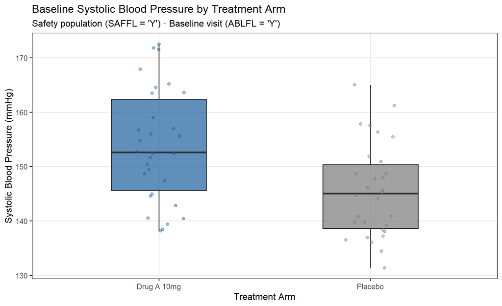

Figure 1. Distribution of Baseline Systolic Blood Pressure by Treatment Arm

```r
advs %>%
  filter(PARAMCD == "SYSBP", ABLFL == "Y", SAFFL == "Y") %>%
  ggplot(aes(x = TRT01P, y = AVAL, fill = TRT01P)) +
  geom_boxplot(width = 0.45, outlier.shape = 21, outlier.size = 2, alpha = 0.7) +
  geom_jitter(aes(color = TRT01P), width = 0.12, alpha = 0.4, size = 1.5) +
  scale_fill_manual(values  = c("Drug A 10mg" = "#1B5E9E", "Placebo" = "#7A7A7A")) +
  scale_color_manual(values = c("Drug A 10mg" = "#1B5E9E", "Placebo" = "#7A7A7A")) +
  labs(
    title    = "Baseline Systolic Blood Pressure by Treatment Arm",
    subtitle = "Safety population (SAFFL = 'Y') · Baseline visit (ABLFL = 'Y')",
    x        = "Treatment Arm",
    y        = "Systolic Blood Pressure (mmHg)",
    fill     = NULL,
    color    = NULL
  ) +
  guides(fill = "none", color = "none")
```

## 8. Change from Baseline in SBP Over Time

Mean CFB ± 95% CI by visit and arm. Primary analysis window: `ANL01FL = "Y"`.

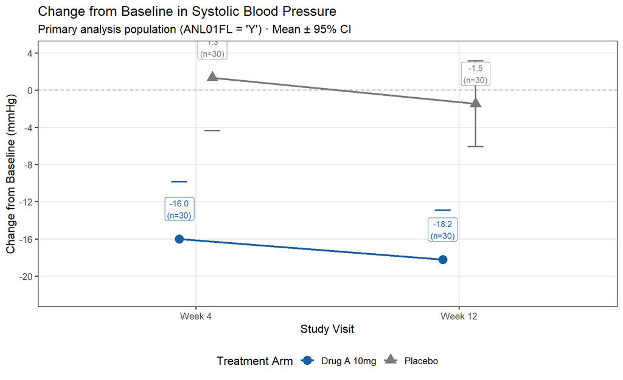

Figure 2. Mean Change from Baseline in Systolic BP by Visit and Treatment Arm (± 95% CI)

```r
# Summary statistics for the primary analysis window (ANL01FL = "Y")
cfb_summary <- advs %>%
  filter(PARAMCD == "SYSBP", ANL01FL == "Y") %>%
  group_by(TRT01P, TRT01PN, AVISIT, AVISITN) %>%
  summarise(
    n    = n(),
    mean = mean(CHG, na.rm = TRUE),
    se   = sd(CHG, na.rm = TRUE) / sqrt(n()),
    ci_l = mean - qt(0.975, df = n - 1) * se,
    ci_u = mean + qt(0.975, df = n - 1) * se,
    .groups = "drop"
  ) %>%
  mutate(
    AVISIT = factor(AVISIT, levels = c("Week 4", "Week 12"))
  )

ggplot(cfb_summary,
       aes(x = AVISIT, y = mean,
           color = TRT01P, group = TRT01P,
           shape = TRT01P)) +
  geom_hline(yintercept = 0, linetype = "dashed", color = "gray60", linewidth = 0.5) +
  geom_errorbar(aes(ymin = ci_l, ymax = ci_u),
                width = 0.12, linewidth = 0.8,
                position = position_dodge(width = 0.25)) +
  geom_line(linewidth = 1.0, position = position_dodge(width = 0.25)) +
  geom_point(size = 4, position = position_dodge(width = 0.25)) +
  geom_label(
    aes(label = sprintf("%.1f\n(n=%d)", mean, n)),
    position = position_dodge(width = 0.25),
    vjust = -0.8, size = 3, label.size = 0.3,
    show.legend = FALSE
  ) +
  scale_color_manual(values = c("Drug A 10mg" = "#1B5E9E", "Placebo" = "#7A7A7A")) +
  scale_shape_manual(values = c("Drug A 10mg" = 16, "Placebo" = 17)) +
  scale_y_continuous(
    limits = c(-22, 4),
    breaks = seq(-20, 4, by = 4)
  ) +
  labs(
    title    = "Change from Baseline in Systolic Blood Pressure",
    subtitle = "Primary analysis population (ANL01FL = 'Y') · Mean ± 95% CI",
    x        = "Study Visit",
    y        = "Change from Baseline (mmHg)",
    color    = "Treatment Arm",
    shape    = "Treatment Arm"
  )
```

## 9. Treatment Difference at Week 12

```r
# Extract Week 12 individual records for the primary analysis
wk12 <- advs %>%
  filter(PARAMCD == "SYSBP", ANL01FL == "Y", AVISIT == "Week 12")

# Two-sample t-test: Drug A vs Placebo change from baseline
drug_chg <- wk12 %>% filter(TRT01P == "Drug A 10mg") %>% pull(CHG)
pbo_chg  <- wk12 %>% filter(TRT01P == "Placebo")     %>% pull(CHG)

ttest_res <- t.test(drug_chg, pbo_chg, var.equal = FALSE)

tibble(
  ` `              = c("Drug A 10mg", "Placebo", "Difference (Drug A − Placebo)"),
  N                = c(length(drug_chg), length(pbo_chg), NA_integer_),
  `Mean CFB (mmHg)`= c(mean(drug_chg), mean(pbo_chg),
                        mean(drug_chg) - mean(pbo_chg)),
  `SD`             = c(sd(drug_chg), sd(pbo_chg), NA_real_),
  `95% CI (lower)` = c(NA, NA, ttest_res$conf.int[1]),
  `95% CI (upper)` = c(NA, NA, ttest_res$conf.int[2]),
  `p-value`        = c(NA, NA, ttest_res$p.value)
) %>%
  kbl(
    caption = "Table 2. Treatment Difference in SBP Change from Baseline at Week 12",
    digits  = c(0, 0, 1, 1, 1, 1, 4)
  ) %>%
  kable_styling(bootstrap_options = c("striped", "hover"), full_width = FALSE) %>%
  row_spec(3, bold = TRUE, background = "#EBF2FB")
```

Table 2. Treatment Difference in SBP Change from Baseline at Week 12

|  | N | Mean CFB (mmHg) | SD | 95% CI (lower) | 95% CI (upper) | p-value |
| --- | --- | --- | --- | --- | --- | --- |
| Drug A 10mg | 30 | -18.2 | 14.2 | NA | NA | NA |
| Placebo | 30 | -1.5 | 12.3 | NA | NA | NA |
| Difference (Drug A − Placebo) | NA | -16.7 | NA | -23.6 | -9.9 | 0 |

## 10. Subgroup Analysis by Age Group

Checking consistency of the treatment effect across age subgroups at Week 12.

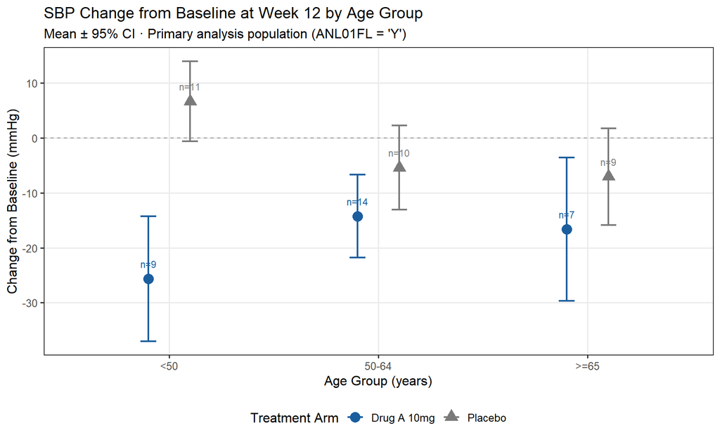

```r
subgroup_summary <- advs %>%
  filter(PARAMCD == "SYSBP", ANL01FL == "Y", AVISIT == "Week 12") %>%
  group_by(AGEGR1, AGEGR1N, TRT01P, TRT01PN) %>%
  summarise(
    n    = n(),
    mean = mean(CHG, na.rm = TRUE),
    se   = sd(CHG,  na.rm = TRUE) / sqrt(n()),
    ci_l = mean - qt(0.975, df = n - 1) * se,
    ci_u = mean + qt(0.975, df = n - 1) * se,
    .groups = "drop"
  ) %>%
  mutate(AGEGR1 = factor(AGEGR1, levels = c("<50", "50-64", ">=65")))

ggplot(subgroup_summary,
       aes(x = AGEGR1, y = mean,
           color = TRT01P, group = TRT01P,
           shape = TRT01P)) +
  geom_hline(yintercept = 0, linetype = "dashed", color = "gray60", linewidth = 0.5) +
  geom_errorbar(aes(ymin = ci_l, ymax = ci_u),
                width = 0.15, linewidth = 0.8,
                position = position_dodge(width = 0.4)) +
  geom_point(size = 4, position = position_dodge(width = 0.4)) +
  geom_text(
    aes(label = sprintf("n=%d", n)),
    position = position_dodge(width = 0.4),
    vjust = -1.5, size = 3, show.legend = FALSE
  ) +
  scale_color_manual(values = c("Drug A 10mg" = "#1B5E9E", "Placebo" = "#7A7A7A")) +
  scale_shape_manual(values = c("Drug A 10mg" = 16, "Placebo" = 17)) +
  labs(
    title    = "SBP Change from Baseline at Week 12 by Age Group",
    subtitle = "Mean ± 95% CI · Primary analysis population (ANL01FL = 'Y')",
    x        = "Age Group (years)",
    y        = "Change from Baseline (mmHg)",
    color    = "Treatment Arm",
    shape    = "Treatment Arm"
  )
```

## 11. Export

Submission-ready ADaM datasets go out as `.xpt` via `haven::write_xpt()`. Writing CSV here for portability.

```r
# In a real submission workflow:
# library(haven)
# write_xpt(adsl, "adsl.xpt", version = 5, name = "ADSL")
# write_xpt(advs, "advs.xpt", version = 5, name = "ADVS")

# For this vignette:
write.csv(adsl, "adsl.csv", row.names = FALSE, na = "")
write.csv(advs, "advs.csv", row.names = FALSE, na = "")

message("ADSL: ", nrow(adsl), " rows, ", ncol(adsl), " columns")
message("ADVS: ", nrow(advs), " rows, ", ncol(advs), " columns")
```

## Summary

References: CDISC ADaM IG v1.3 · CDISC SDTM IG v3.4 · FDA Study Data Technical Conformance Guide (2022)

Synthetic SDTM source data was generated with AI assistance; the ADaM derivations, QC checks, and analysis are my own.

*Vignette produced in R 4.6.0 · dplyr · lubridate · ggplot2 · gtsummary · kableExtra*